# EasyVisa Project

## Boosting - Model Building and Hyperparameter Tuning

### AdaBoost Classifier

```python
ab_classifier = AdaBoostClassifier(random_state=1)  ## Complete the code to define AdaBoost Classifier with random state = 1
ab_classifier.fit(X_train,y_train) ## Complete the code to fit AdaBoost Classifier on the train data
```

```
AdaBoostClassifier(random_state=1)
```

#### Checking model performance on training set

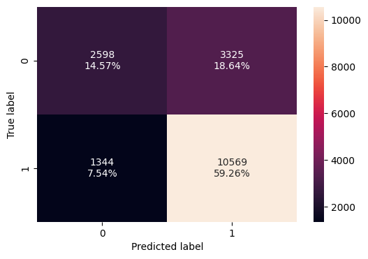

```python
confusion_matrix_sklearn(ab_classifier,X_train,y_train) ## Complete the code to create confusion matrix for train data
```

```python
ab_classifier_model_train_perf = model_performance_classification_sklearn(ab_classifier,X_train,y_train) ## Complete the code to check performance on train data
ab_classifier_model_train_perf
```

|  | Accuracy | Recall | Precision | F1 |
| --- | --- | --- | --- | --- |
| 0 | 0.738226 | 0.887182 | 0.760688 | 0.81908 |

#### Checking model performance on test set

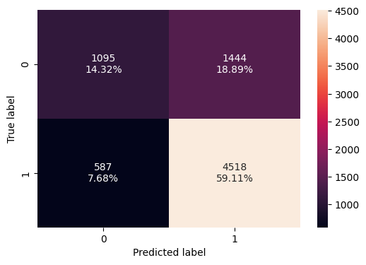

```python
confusion_matrix_sklearn(ab_classifier,X_test,y_test) ## Complete the code to create confusion matrix for test data
```

```python
ab_classifier_model_test_perf = model_performance_classification_sklearn(ab_classifier,X_test,y_test)  ## Complete the code to check performance for test data
ab_classifier_model_test_perf
```

|  | Accuracy | Recall | Precision | F1 |
| --- | --- | --- | --- | --- |
| 0 | 0.734301 | 0.885015 | 0.757799 | 0.816481 |

*Observations*

The F1 scores for the train and test data are 0.819 and 0.816 respectively. The model generalizes well and avoids significant overfitting or underfitting.

Let's subject it to hyperparameter tuning to see what happens with the model performance.

### Hyperparameter Tuning - AdaBoost Classifier

```python
# Choose the type of classifier.
abc_tuned = AdaBoostClassifier(random_state=1)

# Grid of parameters to choose from
parameters = {
    # Let's try different max_depth for base_estimator
    "base_estimator": [
        DecisionTreeClassifier(max_depth=1, class_weight="balanced", random_state=1),
        DecisionTreeClassifier(max_depth=2, class_weight="balanced", random_state=1),
        DecisionTreeClassifier(max_depth=3, class_weight="balanced", random_state=1),
    ],
    "n_estimators": [60, 100, 10],
    "learning_rate": [0.1, 0.4, 0.1],
}

# Type of scoring used to compare parameter  combinations
acc_scorer = metrics.make_scorer(metrics.f1_score)

# Run the grid search
## Complete the code to run grid search with cv = 5
grid_obj = GridSearchCV(abc_tuned, parameters, scoring=scorer,cv=5)

## Complete the code to fit the grid_obj on train data
grid_obj = grid_obj.fit(X_train, y_train)

# Set the clf to the best combination of parameters
abc_tuned = grid_obj.best_estimator_

# Fit the best algorithm to the data.
abc_tuned.fit(X_train, y_train)
```

```
AdaBoostClassifier(base_estimator=DecisionTreeClassifier(class_weight='balanced',
                                                         max_depth=1,
                                                         random_state=1),
                   learning_rate=0.1, n_estimators=10, random_state=1)
```

### Checking model performance on training set

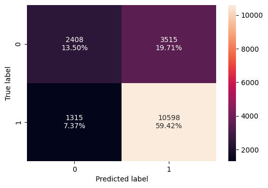

```python
confusion_matrix_sklearn(abc_tuned,X_train,y_train) ## Complete the code to create confusion matrix for train data on tuned estimator
```

```python
abc_tuned_model_train_perf = model_performance_classification_sklearn(abc_tuned,X_train,y_train)  ## Complete the code to check performance for train data on tuned estimator
abc_tuned_model_train_perf
```

|  | Accuracy | Recall | Precision | F1 |
| --- | --- | --- | --- | --- |
| 0 | 0.729199 | 0.889616 | 0.750939 | 0.814416 |

#### Checking model performance on test set

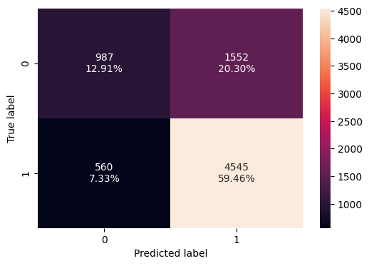

```python
confusion_matrix_sklearn(abc_tuned,X_test,y_test) ## Complete the code to create confusion matrix for test data on tuned estimator
```

```python
abc_tuned_model_test_perf = model_performance_classification_sklearn(abc_tuned,X_test,y_test)  ## Complete the code to check performance for test data on tuned estimator
abc_tuned_model_test_perf
```

|  | Accuracy | Recall | Precision | F1 |
| --- | --- | --- | --- | --- |
| 0 | 0.723705 | 0.890304 | 0.745449 | 0.811462 |

*Observations*

The F1 Score has remained fairly stable after the hyperparameter tuning, confirming that the model generalizes well and avoids significant overfitting or underfitting.

### Gradient Boosting Classifier

```python
gb_classifier = GradientBoostingClassifier(random_state=1) ## Complete the code to define Gradient Boosting Classifier with random state = 1
gb_classifier.fit(X_train,y_train) ## Complete the code to fit Gradient Boosting Classifier on the train data
```

```
GradientBoostingClassifier(random_state=1)
```

#### Checking model performance on training set

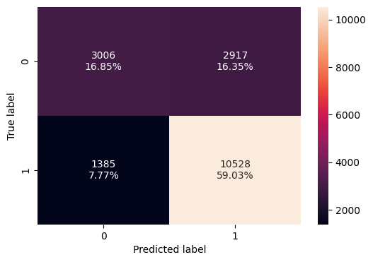

```python
confusion_matrix_sklearn(gb_classifier,X_train,y_train) ## Complete the code to create confusion matrix for train data
```

```python
gb_classifier_model_train_perf = model_performance_classification_sklearn(gb_classifier,X_train,y_train) ## Complete the code to check performance on train data
gb_classifier_model_train_perf
```

|  | Accuracy | Recall | Precision | F1 |
| --- | --- | --- | --- | --- |
| 0 | 0.758802 | 0.88374 | 0.783042 | 0.830349 |

#### Checking model performance on test set

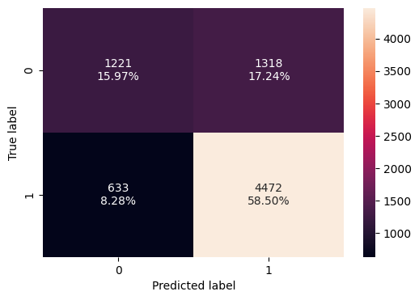

```python
confusion_matrix_sklearn(gb_classifier,X_test,y_test) ## Complete the code to create confusion matrix for test data
```

```python
gb_classifier_model_test_perf = model_performance_classification_sklearn(gb_classifier,X_test,y_test) ## Complete the code to check performance on test data
gb_classifier_model_test_perf
```

|  | Accuracy | Recall | Precision | F1 |
| --- | --- | --- | --- | --- |
| 0 | 0.744767 | 0.876004 | 0.772366 | 0.820927 |

*Observations*

The F1 scores for the train and test data are 0.83 and 0.82 respectively. The model generalizes well and avoids overfitting or underfitting.

Let's subject it to hyperparameter tuning to see what happens with the model performance, whether it can be improved.

### Hyperparameter Tuning - Gradient Boosting Classifier

```python
# Choose the type of classifier.
gbc_tuned = GradientBoostingClassifier(
    init=AdaBoostClassifier(random_state=1), random_state=1
)

# Grid of parameters to choose from
parameters = {
    "n_estimators": np.arange(50,110,25),
    "subsample": [0.7,0.9],
    "max_features": [0.7, 0.8, 0.9, 1],
    "learning_rate": [0.01,0.1,0.05],
}

# Type of scoring used to compare parameter combinations
acc_scorer = metrics.make_scorer(metrics.f1_score)

# Run the grid search
grid_obj = GridSearchCV(gbc_tuned, parameters, scoring=scorer,cv=5) ## Complete the code to run grid search with cv = 5
grid_obj = grid_obj.fit(X_train, y_train) ## Complete the code to fit the grid_obj on train data

# Set the clf to the best combination of parameters
gbc_tuned = grid_obj.best_estimator_

# Fit the best algorithm to the data.
gbc_tuned.fit(X_train, y_train)
```

```
GradientBoostingClassifier(init=AdaBoostClassifier(random_state=1),
                           max_features=0.9, n_estimators=50, random_state=1,
                           subsample=0.9)
```

#### Checking model performance on training set

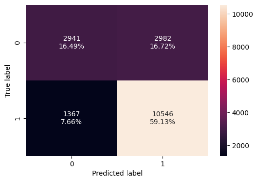

```python
## Complete the code to create confusion matrix for train data on tuned estimator
confusion_matrix_sklearn(gbc_tuned,X_train,y_train)
```

```python
## Complete the code to check performance for train data on tuned estimator
gbc_tuned_model_train_perf = model_performance_classification_sklearn(gbc_tuned,X_train,y_train)
gbc_tuned_model_train_perf
```

|  | Accuracy | Recall | Precision | F1 |
| --- | --- | --- | --- | --- |
| 0 | 0.756167 | 0.885251 | 0.779568 | 0.829055 |

#### Checking model performance on test set

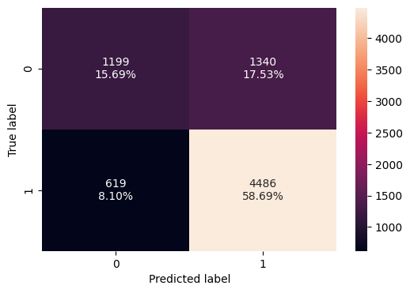

```python
## Complete the code to create confusion matrix for test data on tuned estimator
confusion_matrix_sklearn(gbc_tuned,X_test,y_test)
```

```python
## Complete the code to check performance for test data on tuned estimator
gbc_tuned_model_test_perf = model_performance_classification_sklearn(gbc_tuned,X_test,y_test)
gbc_tuned_model_test_perf
```

|  | Accuracy | Recall | Precision | F1 |
| --- | --- | --- | --- | --- |
| 0 | 0.743721 | 0.878746 | 0.769997 | 0.820785 |

After hyperparameter tuning, there isn't much change in the performance of the model.

We can conclude that the model generalizes well and avoids overfitting or underfitting.

### XGBoost Classifier

```python
from xgboost import XGBClassifier # Import the XGBClassifier class

xgb_classifier = XGBClassifier(random_state=1, eval_metric="logloss") ## Complete the code to define XGBoost Classifier with random state = 1 and eval_metric="logloss"
xgb_classifier.fit(X_train,y_train) ## Complete the code to fit XGBoost Classifier on the train data
```

```
XGBClassifier(base_score=None, booster=None, callbacks=None,
              colsample_bylevel=None, colsample_bynode=None,
              colsample_bytree=None, device=None, early_stopping_rounds=None,
              enable_categorical=False, eval_metric='logloss',
              feature_types=None, gamma=None, grow_policy=None,
              importance_type=None, interaction_constraints=None,
              learning_rate=None, max_bin=None, max_cat_threshold=None,
              max_cat_to_onehot=None, max_delta_step=None, max_depth=None,
              max_leaves=None, min_child_weight=None, missing=nan,
              monotone_constraints=None, multi_strategy=None, n_estimators=None,
              n_jobs=None, num_parallel_tree=None, random_state=1, ...)
```

#### Checking model performance on training set

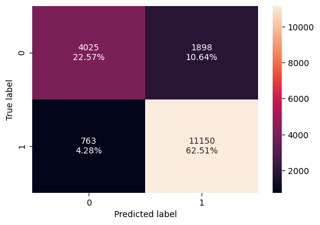

```python
confusion_matrix_sklearn(xgb_classifier,X_train,y_train) ## Complete the code to create confusion matrix for train data
```

```python
xgb_classifier_model_train_perf = model_performance_classification_sklearn(xgb_classifier,X_train,y_train) ## Complete the code to check performance on train data
xgb_classifier_model_train_perf
```

|  | Accuracy | Recall | Precision | F1 |
| --- | --- | --- | --- | --- |
| 0 | 0.850807 | 0.935952 | 0.854537 | 0.893394 |

#### Checking model performance on test set

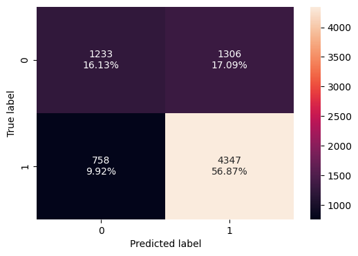

```python
confusion_matrix_sklearn(xgb_classifier,X_test,y_test) ## Complete the code to create confusion matrix for test data
```

```python
xgb_classifier_model_test_perf = model_performance_classification_sklearn(xgb_classifier,X_test,y_test) ## Complete the code to check performance on train data
xgb_classifier_model_test_perf
```

|  | Accuracy | Recall | Precision | F1 |
| --- | --- | --- | --- | --- |
| 0 | 0.729984 | 0.851518 | 0.768972 | 0.808143 |

*Observations* The train data has an F1 Score of 0.893 whilst the test data has an F1 score of 0.808. There appears to be some overfitting in the train data.

Let's subject the model to hyperparameter tuning to see how the model will perform.

### Hyperparameter Tuning - XGBoost Classifier

```python
# Choose the type of classifier.
xgb_tuned = XGBClassifier(random_state=1, eval_metric="logloss")

# Grid of parameters to choose from
parameters = {
    "n_estimators": np.arange(50,110,25),
    "scale_pos_weight": [1,2,5],
    "subsample": [0.9, 1],
    "learning_rate": [0.01,0.1,0.05],
    "gamma": [1,3]
}

# Type of scoring used to compare parameter combinations
acc_scorer = metrics.make_scorer(metrics.f1_score)

# Run the grid search
# Changed 'xbg_tuned' to 'xgb_tuned' to use the correct variable name
grid_obj = GridSearchCV(xgb_tuned, parameters, scoring=scorer,cv=5) ## Complete the code to run grid search with cv = 5
grid_obj = grid_obj.fit(X_train, y_train) ## Complete the code to fit the grid_obj on train data

# Set the clf to the best combination of parameters
xgb_tuned = grid_obj.best_estimator_

# Fit the best algorithm to the data.
xgb_tuned.fit(X_train, y_train)
```

```
XGBClassifier(base_score=None, booster=None, callbacks=None,
              colsample_bylevel=None, colsample_bynode=None,
              colsample_bytree=None, device=None, early_stopping_rounds=None,
              enable_categorical=False, eval_metric='logloss',
              feature_types=None, gamma=3, grow_policy=None,
              importance_type=None, interaction_constraints=None,
              learning_rate=0.05, max_bin=None, max_cat_threshold=None,
              max_cat_to_onehot=None, max_delta_step=None, max_depth=None,
              max_leaves=None, min_child_weight=None, missing=nan,
              monotone_constraints=None, multi_strategy=None, n_estimators=50,
              n_jobs=None, num_parallel_tree=None, random_state=1, ...)
```

#### Checking model performance on training set

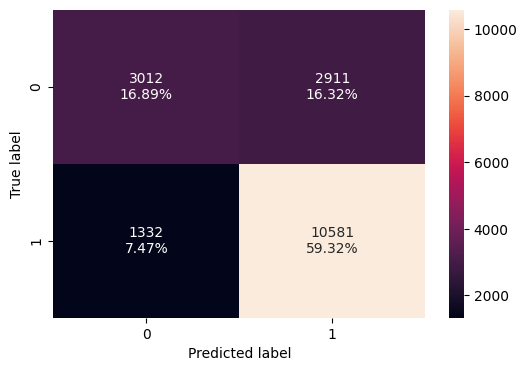

```python
confusion_matrix_sklearn(xgb_tuned, X_train, y_train) ## Complete the code to create confusion matrix for train data on tuned estimator
```

```python
xgb_tuned_model_train_perf = model_performance_classification_sklearn(xgb_tuned, X_train, y_train) ## Complete the code to check performance for train data on tuned estimator
print("Training Performance:")
print(xgb_tuned_model_train_perf)
```

```
Training Performance:
   Accuracy    Recall  Precision        F1
0   0.76211  0.888189   0.784243  0.832986
```

#### Checking model performance on test set

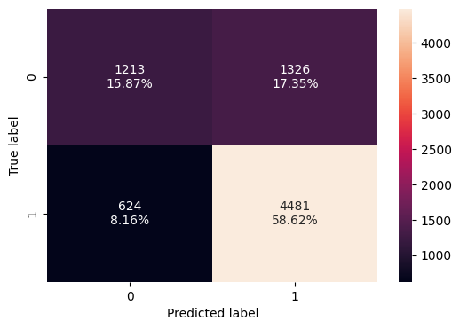

```python
confusion_matrix_sklearn(xgb_tuned, X_test, y_test) ## Complete the code to create confusion matrix for test data
```

```python
xgb_tuned_model_test_perf = model_performance_classification_sklearn(xgb_tuned, X_test, y_test) ## Complete the code to check performance for test data
print("\nTest Performance:")
print(xgb_tuned_model_test_perf)
```

```
Test Performance:
   Accuracy    Recall  Precision        F1
0  0.744898  0.877767   0.771655  0.821298
```

*Observations*

After hyperparameter tuning, we can conclude that the model generalizes well and avoids overfitting or underfitting.

## Stacking Classifier

```python
estimators = [
    ("AdaBoost", ab_classifier),
    ("Gradient Boosting", gbc_tuned),
    ("Random Forest", rf_tuned),
    ("XGBoost", xgb_classifier)
]

final_estimator = ab_classifier

## Complete the code to define Stacking Classifier
stacking_classifier = StackingClassifier(estimators=estimators,final_estimator=final_estimator)

## Complete the code to fit Stacking Classifier on the train data
stacking_classifier.fit(X_train,y_train)
```

```
StackingClassifier(estimators=[('AdaBoost', AdaBoostClassifier(random_state=1)),
                               ('Gradient Boosting',
                                GradientBoostingClassifier(init=AdaBoostClassifier(random_state=1),
                                                           max_features=0.9,
                                                           n_estimators=50,
                                                           random_state=1,
                                                           subsample=0.9)),
                               ('Random Forest',
                                RandomForestClassifier(max_depth=10,
                                                       min_samples_split=3,
                                                       n_estimators=40,
                                                       oob_score=True,
                                                       random_state=1)),...
                                              interaction_constraints=None,
                                              learning_rate=None, max_bin=None,
                                              max_cat_threshold=None,
                                              max_cat_to_onehot=None,
                                              max_delta_step=None,
                                              max_depth=None, max_leaves=None,
                                              min_child_weight=None,
                                              missing=nan,
                                              monotone_constraints=None,
                                              multi_strategy=None,
                                              n_estimators=None, n_jobs=None,
                                              num_parallel_tree=None,
                                              random_state=1, ...))],
                   final_estimator=AdaBoostClassifier(random_state=1))
```

### Checking model performance on training set

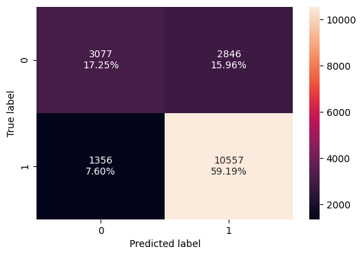

```python
## Complete the code to create confusion matrix for train data
confusion_matrix_sklearn(stacking_classifier,X_train,y_train)
```

```python
## Complete the code to check performance on train data
stacking_classifier_model_train_perf = model_performance_classification_sklearn(stacking_classifier,X_train,y_train)
stacking_classifier_model_train_perf
```

|  | Accuracy | Recall | Precision | F1 |
| --- | --- | --- | --- | --- |
| 0 | 0.764409 | 0.886175 | 0.787659 | 0.834018 |

### Checking model performance on test set

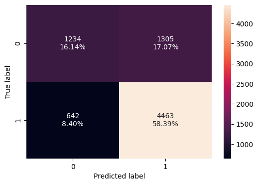

```python
## Complete the code to create confusion matrix for test data
confusion_matrix_sklearn(stacking_classifier,X_test,y_test)
```

```python
## Complete the code to check performance on test data
stacking_classifier_model_test_perf = model_performance_classification_sklearn(stacking_classifier,X_test,y_test)
stacking_classifier_model_test_perf
```

|  | Accuracy | Recall | Precision | F1 |
| --- | --- | --- | --- | --- |
| 0 | 0.74529 | 0.874241 | 0.773752 | 0.820933 |

*Observations*

The model is performing well on both the train and test data. There's no overfitting or underfitting.